# NKipuw_Homework1

Neshita Kipuw

2024-10-15

```r
library(limma)
library(ggplot2)
library(dplyr)
library(reshape2)
```

# 1 Question 1

## 1.1 Creating a function to calculate the mean of a numeric vector, then compare to R’s built-in mean() function.

### 1.1.1 Create a function

```r
#### Create a function to calculate the mean of numeric vector####
calc_mean <- function(x) {
  if(!is.numeric(x)){
    stop("Input must be a numeric vector.")
  }

  #### take the sum of all the numeric vector####
  sum <- 0
  for (i in 1:length(x)) {
    sum <- sum +x[i]
  }

  ####calculate the mean ####
  mean <- sum / length(x)

  return(mean)
}
```

### 1.1.2 Obtain five random (integer) numbers between 1-20

```r
#### Get 5 random numbers between 1 and 20 ####
random_num <- sample(1:20, 5)
random_num
```

```
## [1]  2  4  6 12 20
```

### 1.1.3 Execute the function with the five random numbers generated

```r
#### Run the function ####
calc_mean(random_num)
```

```
## [1] 8.8
```

### 1.1.4 Compare the result with R’s built-in mean() function

```r
#### Compare to R's built-in mean function ####
mean(random_num)
```

```
## [1] 8.8
```

# 2 Question 2

## 2.1 2a. Explain the code: what it does, what is printed/not, and why

### 2.1.1 The code below creates a matrix of 3 rows x 3 columns dimension. The values are integers from 1-9 and are arranged by column, because R defaults to filling in each row per column order to fill matrices. Since there is no specific command to print after the creation of the matrix, a successful run of this code will not print anything.

```r
mat <- matrix(1:9, nrow = 3, ncol = 3)
```

### 2.1.2 The code below will look for the index of the maximum number in the matrix. Because of the order of the matrix, the maximum number is 9 and it is found in the ninth index, therefore R prints the index.

```r
which.max(mat)
```

```
## [1] 9
```

### 2.1.3 The purpose of the code: which.max(as.data.frame(mat)), is to look for the index of the maximum number/value in a data frame. However, when run the result prints an error message: *Error in which.max(as.data.frame(mat)): ‘list’ object cannot be coerced to type ‘double’*, because the matrix is not a data frame. The function which.max() only works with vectors, so it won’t work for a data frame.

### 2.1.4 The code: mat[1:9,] , is asking to subset the matrix from rows 1-9 and all of the columns. When run, the result prints an error message: *Error in mat[1:9, ]: subscript out of bounds*. This is because the matrix only has 3 rows and it cannot call upon non-existent rows.

### 2.1.5 The code: mat[,1:9], is asking to subset the matrix from columns 1-9 and all of the rows. When run, the result is an error message: *Error in mat[,1:9]: subscript out of bounds*. This is because the matrix only has 3 columns and similarly with the code above it cannot call upon non-existent columns.

## 2.2 2b. Explain the code: what it does, what is printed/not, and why

### 2.2.1 The code below creates a matrix of 3 rows x 3 columns dimension. The values are integers from 1-5, two sevens, and two NA (which is missing value). The argument *byrow=T* forces the matrix to be filled per row instead of the R default of filling in per column order. The result prints the matrix and its values in row x column dimension, because the code specifies a print() function.

```r
m <- matrix(c(1:5,NA,7,7,NA), nrow=3,ncol=3,byrow=T); print(m)
```

```
##      [,1] [,2] [,3]
## [1,]    1    2    3
## [2,]    4    5   NA
## [3,]    7    7   NA
```

### 2.2.2 The code below assigns a null object to the vector, numbers, and initiates an empty vector which will be populated in the next line of code inside a for loop. There is no command to print results, so the command will run in the background and nothing is printed.

```r
numbers <- NULL
```

### 2.2.3 The code is a for loop that iterates over values *i* from 1-4 sequentially. Inside the loop, the code takes the i-th row of matrix *m*, and assigns is to the temporary variable *temp*. However, the matrix only consists of 3 rows and will execute the loop for i=1-3 until it 1=4 which will try to access a non-existent row. The result is an error message printed, *Error in m[i, ] : subscript out of bounds*. This causes the program to exit the loop without executing the last line of code, which was intended to append the values in *temp* to the *numbers* vector at each iteration of the loop.

```r
for(i in 1:4){
  temp <- m[i,]
  numbers <- c(numbers, temp)
}
```

# 3 Question 3

```r
GEODataDownload <- function(DS, gpl, gsm, PlateAnnotInfo, GenerateMetaData, Technology){
  library(DESeq2); library(limma); library(data.table)
  if(Technology == "Array"){
    gset <- getGEO(DS)
    if(length(gset) > 1) idx <- grep(gpl, attr(gset, "names")) else idx <- 1
    gset <- gset[[idx]]
    fvarLabels(gset) <- make.names(fvarLabels(gset))
    comp <- gsub(" ", "", gsm)
    comp <- gsub(",", "", comp)
    gsms <- paste0(comp)
    #### Set up raw names ####
    sml <- c()
    for(i in 1:nchar(gsms)){ sml[i] <- substr(gsms,i,i)}
    ex <- exprs(gset)
    qx <- as.numeric(quantile(ex, c(0., 0.25, 0.5, 0.75, 0.99, 1.0), na.rm=T))
    LogC <- (qx[5] > 100) ||
      (qx[6]-qx[1] > 50 && qx[2] > 0) ||
      (qx[2] > 0 && qx[2] < 1 && qx[4] < 2)
    if(LogC){ ex[which(ex <= 0)] <- NaN
    exprs(gset) <- log2(ex) }
    sml <- paste("G", sml, sep="")
    f1 <- as.factor(sml)
    gset$description2 <- f1
    design <- model.matrix(~description2 + 0, gset)
    colnames(design) <- levels(f1)
    fit <- lmFit(gset, design)
    cont.matrix <- makeContrasts(G1-G0, levels = design)
    fit2 <- contrasts.fit(fit, cont.matrix)
    fit2 <- eBayes(fit2, 0.01)
    tT <- topTable(fit2, adjust="fdr", sort.by = "B", number = 25000000000)
    #### subset ####
    ex2 <- data.table(subset(tT, select=c("ID", "logFC", "P.Value", "adj.P.Val")))
    ex2$ID <- as.character(ex2$ID)
    #### annotate with gene names ####
    plat <- PlateAnnotInfo[GPLID == gpl,][,!"GPLID", with = FALSE]
    if(nrow(plat) == 0){ print(paste("There is no annotation information available for", gpl)) }
    plat$ID <- as.character(plat$ID)
    plat <- plat[!duplicated(plat$ID),]
    ex2 <- merge(plat, ex2, by = "ID")
    ex2$ID <- as.character(ex2$ID)
    exraw <- data.table(ex)
    exraw$ID <- as.character(rownames(ex))
    #### annotate raw data with gene names ####
    ex2 <- merge(ex2, exraw, by = "ID")
    #### Generate Meta Data ####
    Pdat <- pData(gset)
    #### Add Meta data ####
    Pdat <- as.data.table(Pdat)
    return(list(Data = ex2, MetaData = Pdat))
  }

  if(Technology == "RNAseq"){
    ACC <- paste("acc=", DS, sep = "")
    file <- paste("file=", DS, "_raw_counts_GRCh38.p13_NCBI.tsv.gz", sep = "")
    comp <- gsub(" ", "", gsm)
    comp <- gsub(",", "", comp)
    gsms <- paste0(comp)
    #### Set up DEG names ####
    urld <- "https://www.ncbi.nlm.nih.gov/geo/download/?format=file&type=rnaseq_counts"
    path <- paste(urld, ACC, file, sep="&");
    tbl <- as.matrix(data.table::fread(path, header=T, colClasses="integer"), rownames="GeneID")
    exraw <- tbl
    apath <- paste(urld, "type=rnaseq_counts", "file=Human.GRCh38.p13.annot.tsv.gz", sep="&")
    annot <- data.table::fread(apath, header=T, quote="", stringsAsFactors=F, data.table=F)
    rownames(annot) <- annot$GeneID
    sml <- strsplit(gsms, split="")[[1]]
    sel <- which(sml != "X")
    sml <- sml[sel]
    tbl <- tbl[ ,sel]
    gs <- factor(sml)
    groups <- make.names(c("Ctrl", "Tx"))
    levels(gs) <- groups
    sample_info <- data.frame(Group = gs, row.names = colnames(tbl))
    keep <- rowSums( tbl >= 10 ) >= min(table(gs))
    tbl <- tbl[keep, ]
    ds <- DESeqDataSetFromMatrix(countData=tbl, colData=sample_info, design= ~Group)
    ds <- DESeq(ds, test="Wald", sfType="poscount")
    r <- results(ds, contrast=c("Group", groups[2], groups[1]), alpha=0.05, pAdjustMethod ="fdr")
    tT <- r[order(r$padj)[1:length(r$padj)],]
    tT <- merge(as.data.frame(tT), annot, by=0, sort=F)
    tT <- subset(tT, select=c("GeneID","padj","pvalue","lfcSE","stat","log2FoldChange","baseMean","Symbol","Description"))
    #### subset ####
    ex2 <- data.table(subset(tT, select=c("GeneID", "Symbol", "Description", "log2FoldChange", "pvalue", "padj")))
    #### Adjust column names ####
    setnames(ex2, c("GeneID", "Symbol", "Description"), c("ENTREZID", "SYMBOL", "GENENAME"))
    #### Get Raw data ####
    GeneID <- as.integer(rownames(exraw))
    exraw <- as.data.table(exraw)
    #### Update column names ####
    exraw$ENTREZID <- GeneID
    #### merge FC and raw data together ####
    mer <- merge(ex2, exraw, by = "ENTREZID")
    return(mer)
  }
}
#### Execute the GEODataDownload function and obtain the RNAseq data set ####
RNAseqData <- GEODataDownload(DS = "GSE220979",
                              gpl = "GPL24676",
                              gsm = "0011",
                              PlateAnnotInfo = "Only needed if the data was generated using MicroArrays",
                              GenerateMetaData = "Only needed if the data was generated using MicroArrays",
                              Technology = "RNAseq")
data.table(head(as.data.frame(RNAseqData),10), filter = 'top', options = list(pageLength = 10, scrollX = TRUE, scrollY = "400px", autoWidth = TRUE))
```

```
##     ENTREZID SYMBOL                                  GENENAME log2FoldChange
##        <int> <char>                                    <char>          <num>
##  1:        1   A1BG                    alpha-1-B glycoprotein    -0.11630165
##  2:        2    A2M                     alpha-2-macroglobulin    -0.21476075
##  3:        9   NAT1                     N-acetyltransferase 1     0.06601760
##  4:       14   AAMP   angio associated migratory cell protein    -0.15332714
##  5:       15  AANAT          aralkylamine N-acetyltransferase     1.66103296
##  6:       16  AARS1                  alanyl-tRNA synthetase 1    -0.08862379
##  7:       18   ABAT          4-aminobutyrate aminotransferase     0.02330961
##  8:       19  ABCA1 ATP binding cassette subfamily A member 1    -0.22823800
##  9:       20  ABCA2 ATP binding cassette subfamily A member 2    -0.24968383
## 10:       21  ABCA3 ATP binding cassette subfamily A member 3     0.45657562
##          pvalue      padj GSM6833488 GSM6833489 GSM6833490 GSM6833491 filter
##           <num>     <num>      <int>      <int>      <int>      <int> <char>
##  1: 0.550635346 0.9985243        220        259        205        196    top
```

[output cut: 21 more lines]

## 3.1 Question 3.a-b. Save downloaded file into the current working directory under a new name, and reload into R environment.

```r
####Define file path to save into working directory####
getwd()
```

```
## [1] "C:/Users/nessi/Documents/RBIF111"
```

```r
file_path <- "~/RBIF111"

####Save the RNAseq data set to the working directory####
saveRDS(RNAseqData, file = "RNAseq_GSE220979_1.rds")

####Reload the file into R environment####
RNAseq_GSE220979_1 <- readRDS("RNAseq_GSE220979_1.rds")
print(head(RNAseq_GSE220979_1))
```

```
## Key: <ENTREZID>
##    ENTREZID SYMBOL                                GENENAME log2FoldChange
##       <int> <char>                                  <char>          <num>
## 1:        1   A1BG                  alpha-1-B glycoprotein    -0.11630165
## 2:        2    A2M                   alpha-2-macroglobulin    -0.21476075
## 3:        9   NAT1                   N-acetyltransferase 1     0.06601760
## 4:       14   AAMP angio associated migratory cell protein    -0.15332714
## 5:       15  AANAT        aralkylamine N-acetyltransferase     1.66103296
## 6:       16  AARS1                alanyl-tRNA synthetase 1    -0.08862379
##         pvalue      padj GSM6833488 GSM6833489 GSM6833490 GSM6833491
##          <num>     <num>      <int>      <int>      <int>      <int>
## 1: 0.550635346 0.9985243        220        259        205        196
## 2: 0.120257172 0.7291627        581        570        465        437
## 3: 0.734379589 0.9985243        228        219        235        192
## 4: 0.143333593 0.7777628       1241       1332       1148        960
## 5: 0.001922966 0.0459447         14         14         47         34
## 6: 0.312687410 0.9544781       3728       3963       3676       2925
```

## 3.2 Question 3.c. Add a new column called Subset_Comparison for sample annotation

```r
####Create a new data frame to group the samples by ctrl vs. Tx ####
new_df <- data.frame(
  Sample_ID = c("GSM6833488", "GSM6833489", "GSM6833490", "GSM6833491"),
  group = c("Ctrl", "Ctrl", "Tx_GFP-Dexa", "Tx_CD9-Dexa")
)

#### Import libraries & Convert data set to long format to merge the sample group####
library(dplyr)
library(reshape2)
RNAseq_GSE220979_2 <- melt(RNAseq_GSE220979_1, id.vars = c("ENTREZID", "SYMBOL", "GENENAME", "log2FoldChange", "pvalue", "padj"),
                           variable.name = "Sample_ID", value.name = "Expression")

####Merge the sample group to the long format data set and append the new column ####
RNAseq_GSE220979_2 <- merge(RNAseq_GSE220979_2, new_df, by = "Sample_ID", all.x = TRUE)

####Append the new column and use a placeholder value####
RNAseq_GSE220979_2$Subset_Comparison <- "Unknown"

####Annotate the samples with correct sample groups####
RNAseq_GSE220979_2$Subset_Comparison <- ifelse(RNAseq_GSE220979_2$group == "Tx_GFP-Dexa", "low-CD9 Dexa Treated",
                                               ifelse(RNAseq_GSE220979_2$group == "Tx_CD9-Dexa", "high-CD9 Treated", "Control in DMSO"))

####Check the resulting converted data set####
print(head(RNAseq_GSE220979_2))
```

```
## Key: <Sample_ID>
##     Sample_ID ENTREZID SYMBOL                                GENENAME
##        <char>    <int> <char>                                  <char>
## 1: GSM6833488        1   A1BG                  alpha-1-B glycoprotein
## 2: GSM6833488        2    A2M                   alpha-2-macroglobulin
## 3: GSM6833488        9   NAT1                   N-acetyltransferase 1
## 4: GSM6833488       14   AAMP angio associated migratory cell protein
## 5: GSM6833488       15  AANAT        aralkylamine N-acetyltransferase
## 6: GSM6833488       16  AARS1                alanyl-tRNA synthetase 1
##    log2FoldChange      pvalue      padj Expression  group Subset_Comparison
##             <num>       <num>     <num>      <int> <char>            <char>
## 1:    -0.11630165 0.550635346 0.9985243        220   Ctrl   Control in DMSO
## 2:    -0.21476075 0.120257172 0.7291627        581   Ctrl   Control in DMSO
## 3:     0.06601760 0.734379589 0.9985243        228   Ctrl   Control in DMSO
## 4:    -0.15332714 0.143333593 0.7777628       1241   Ctrl   Control in DMSO
## 5:     1.66103296 0.001922966 0.0459447         14   Ctrl   Control in DMSO
## 6:    -0.08862379 0.312687410 0.9544781       3728   Ctrl   Control in DMSO
```

```r
print(tail(RNAseq_GSE220979_2))
```

```
## Key: <Sample_ID>
##     Sample_ID  ENTREZID       SYMBOL                                 GENENAME
##        <char>     <int>       <char>                                   <char>
## 1: GSM6833491 114483834  ABCF2-H2BK1                  ABCF2-H2BK1 readthrough
## 2: GSM6833491 114818278 ZNF71-SMIM17 ZNF71-SMIM17 readthrough (NMD candidate)
## 3: GSM6833491 114841035 LOC114841035     Uncharacterized protein LOC114841035
## 4: GSM6833491 115253422 DUS4L-BCAP29                 DUS4L-BCAP29 readthrough
## 5: GSM6833491 115271120     LDLR-AS1                     LDLR antisense RNA 1
## 6: GSM6833491 115308161 LOC115308161             uncharacterized LOC115308161
##    log2FoldChange    pvalue      padj Expression       group Subset_Comparison
##             <num>     <num>     <num>      <int>      <char>            <char>
## 1:    -0.08501444 0.4873959 0.9985243        593 Tx_CD9-Dexa  high-CD9 Treated
## 2:    -0.21058427 0.6412187 0.9985243         26 Tx_CD9-Dexa  high-CD9 Treated
## 3:    -0.10565028 0.7782359 0.9985243         38 Tx_CD9-Dexa  high-CD9 Treated
## 4:     0.19574193 0.1433955 0.7777893        523 Tx_CD9-Dexa  high-CD9 Treated
## 5:    -0.45604095 0.1247732 0.7397399         73 Tx_CD9-Dexa  high-CD9 Treated
## 6:    -0.05334945 0.8243823 0.9985243        116 Tx_CD9-Dexa  high-CD9 Treated
```

```r
#### Get avg expression####
avg_expression <- RNAseq_GSE220979_2 %>%
  group_by(Sample_ID) %>%
  summarise(avg_expression = mean(Expression, na.rm=TRUE))

RNAseq_GSE220979_3 <- RNAseq_GSE220979_2 %>%
  left_join(avg_expression, by = "Sample_ID")

print(head(RNAseq_GSE220979_3))
```

```
## Key: <Sample_ID>
##     Sample_ID ENTREZID SYMBOL                                GENENAME
##        <char>    <int> <char>                                  <char>
## 1: GSM6833488        1   A1BG                  alpha-1-B glycoprotein
## 2: GSM6833488        2    A2M                   alpha-2-macroglobulin
## 3: GSM6833488        9   NAT1                   N-acetyltransferase 1
## 4: GSM6833488       14   AAMP angio associated migratory cell protein
## 5: GSM6833488       15  AANAT        aralkylamine N-acetyltransferase
## 6: GSM6833488       16  AARS1                alanyl-tRNA synthetase 1
##    log2FoldChange      pvalue      padj Expression  group Subset_Comparison
##             <num>       <num>     <num>      <int> <char>            <char>
## 1:    -0.11630165 0.550635346 0.9985243        220   Ctrl   Control in DMSO
## 2:    -0.21476075 0.120257172 0.7291627        581   Ctrl   Control in DMSO
## 3:     0.06601760 0.734379589 0.9985243        228   Ctrl   Control in DMSO
## 4:    -0.15332714 0.143333593 0.7777628       1241   Ctrl   Control in DMSO
## 5:     1.66103296 0.001922966 0.0459447         14   Ctrl   Control in DMSO
## 6:    -0.08862379 0.312687410 0.9544781       3728   Ctrl   Control in DMSO
##    avg_expression
##             <num>
## 1:       1138.628
## 2:       1138.628
## 3:       1138.628
## 4:       1138.628
## 5:       1138.628
## 6:       1138.628
```

```r
print(tail(RNAseq_GSE220979_3))
```

```
## Key: <Sample_ID>
##     Sample_ID  ENTREZID       SYMBOL                                 GENENAME
##        <char>     <int>       <char>                                   <char>
## 1: GSM6833491 114483834  ABCF2-H2BK1                  ABCF2-H2BK1 readthrough
## 2: GSM6833491 114818278 ZNF71-SMIM17 ZNF71-SMIM17 readthrough (NMD candidate)
## 3: GSM6833491 114841035 LOC114841035     Uncharacterized protein LOC114841035
## 4: GSM6833491 115253422 DUS4L-BCAP29                 DUS4L-BCAP29 readthrough
## 5: GSM6833491 115271120     LDLR-AS1                     LDLR antisense RNA 1
## 6: GSM6833491 115308161 LOC115308161             uncharacterized LOC115308161
##    log2FoldChange    pvalue      padj Expression       group Subset_Comparison
##             <num>     <num>     <num>      <int>      <char>            <char>
## 1:    -0.08501444 0.4873959 0.9985243        593 Tx_CD9-Dexa  high-CD9 Treated
## 2:    -0.21058427 0.6412187 0.9985243         26 Tx_CD9-Dexa  high-CD9 Treated
## 3:    -0.10565028 0.7782359 0.9985243         38 Tx_CD9-Dexa  high-CD9 Treated
## 4:     0.19574193 0.1433955 0.7777893        523 Tx_CD9-Dexa  high-CD9 Treated
## 5:    -0.45604095 0.1247732 0.7397399         73 Tx_CD9-Dexa  high-CD9 Treated
## 6:    -0.05334945 0.8243823 0.9985243        116 Tx_CD9-Dexa  high-CD9 Treated
##    avg_expression
##             <num>
## 1:       990.7486
## 2:       990.7486
## 3:       990.7486
## 4:       990.7486
## 5:       990.7486
## 6:       990.7486
```

```r
RNAseq_GSE220979_3a <- RNAseq_GSE220979_3[,-1]
RNAseq_GSE220979_4a <- dcast(RNAseq_GSE220979_3a, ENTREZID + SYMBOL + GENENAME + log2FoldChange + pvalue + padj + avg_expression ~ Subset_Comparison, value.var = "Expression")

RNAseq_GSE220979_4 <- dcast(RNAseq_GSE220979_3, ENTREZID + SYMBOL + GENENAME + log2FoldChange + pvalue + padj + Subset_Comparison + avg_expression ~ Sample_ID, value.var = "Expression")
```

## 3.3 Question 3.d. Calculate average gene expression level for each sample, then plot using Histogram, Boxplot, Stripchart, Stem-and-leaf, Dotchart, and Sorted in Ascending order.

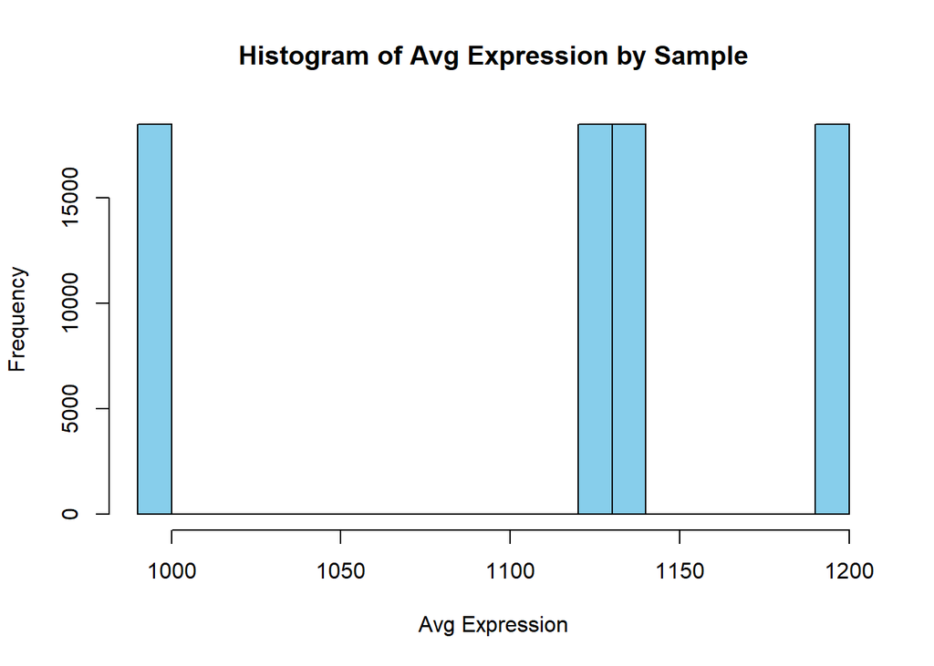

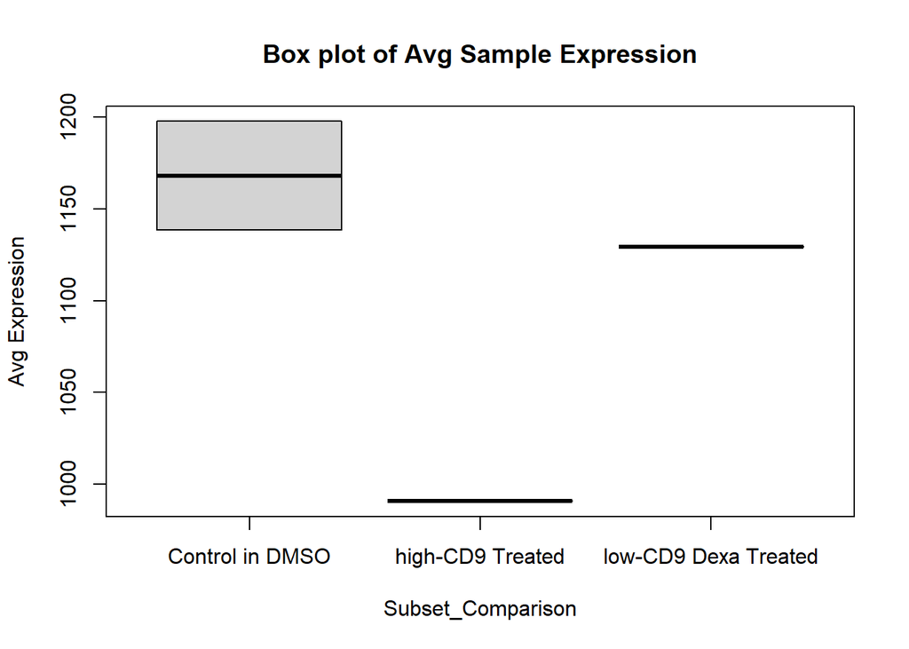

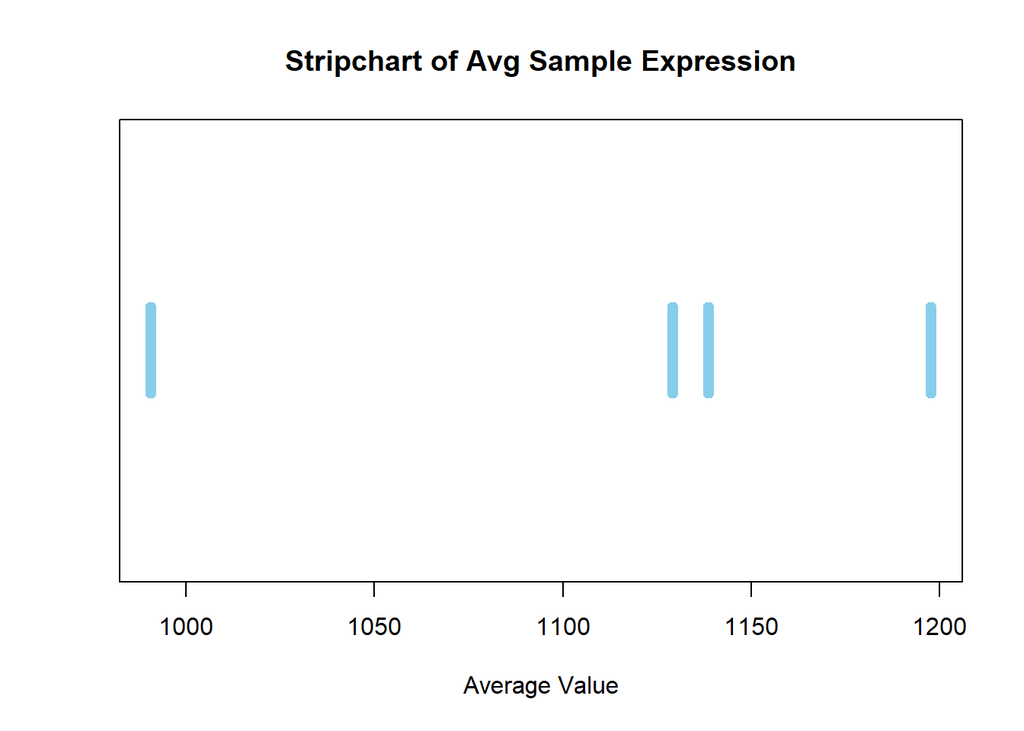

```
##
##   The decimal point is 1 digit(s) to the right of the |
##
##    99 | 11111111111111111111111111111111111111111111111111111111111111111111+18389
##   100 |
##   101 |
##   102 |
##   103 |
##   104 |
##   105 |
##   106 |
##   107 |
##   108 |
##   109 |
##   110 |
##   111 |
##   112 | 99999999999999999999999999999999999999999999999999999999999999999999+18389
##   113 | 99999999999999999999999999999999999999999999999999999999999999999999+18389
##   114 |
##   115 |
##   116 |
##   117 |
##   118 |
##   119 | 88888888888888888888888888888888888888888888888888888888888888888888+18389
```

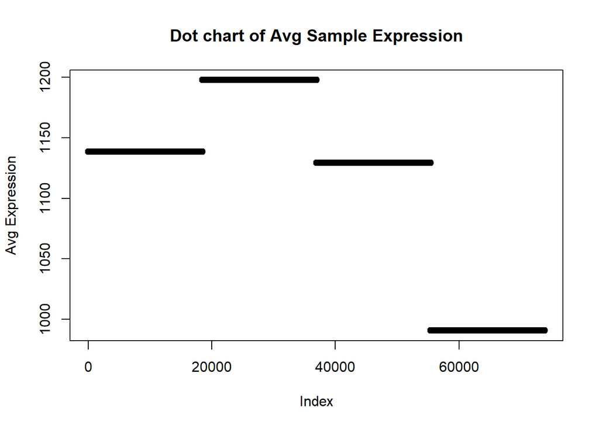

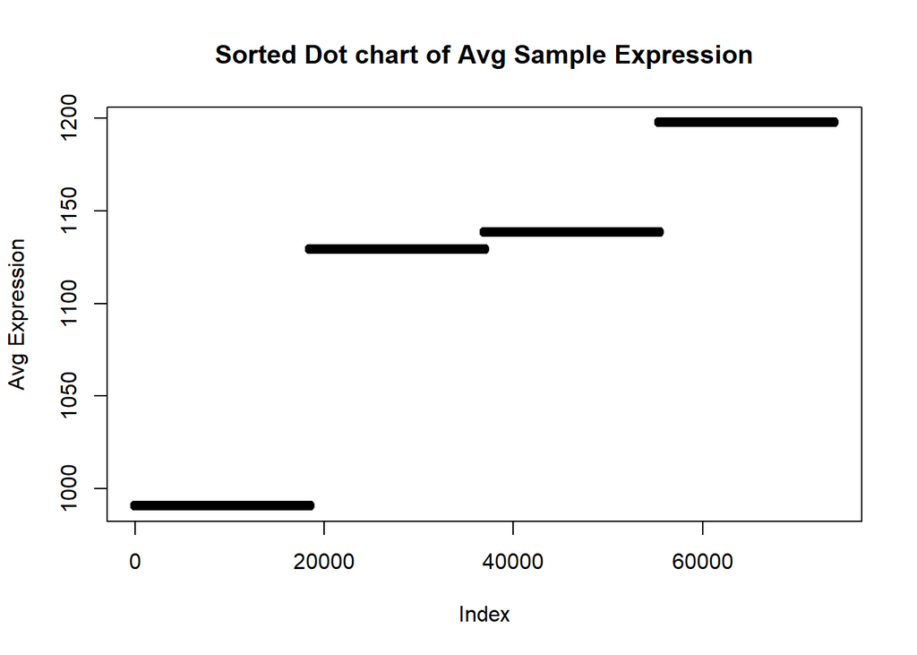

## 3.4 Question 3.e. Calculate average gene expression levels for each gene.

```r
#### Calculate the mean for each gene ####
gene_avgexpress <- aggregate(Expression ~ ENTREZID + SYMBOL + Subset_Comparison, data = RNAseq_GSE220979_3a, FUN = mean)
print(head(gene_avgexpress))
```

```
##   ENTREZID   SYMBOL Subset_Comparison Expression
## 1        1     A1BG   Control in DMSO      239.5
## 2   503538 A1BG-AS1   Control in DMSO      181.5
## 3        2      A2M   Control in DMSO      575.5
## 4   144571  A2M-AS1   Control in DMSO       23.5
## 5     8086     AAAS   Control in DMSO      967.0
## 6    65985     AACS   Control in DMSO      417.5
```

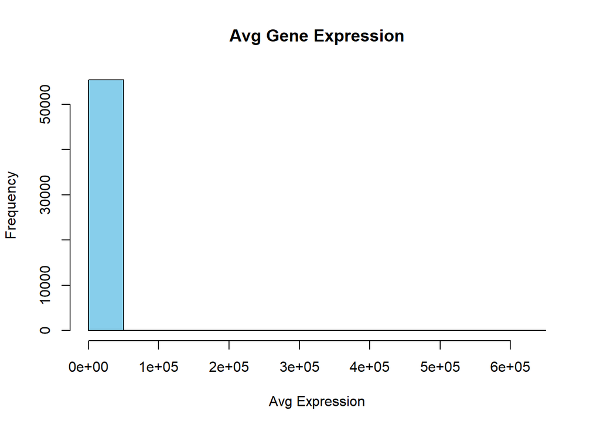

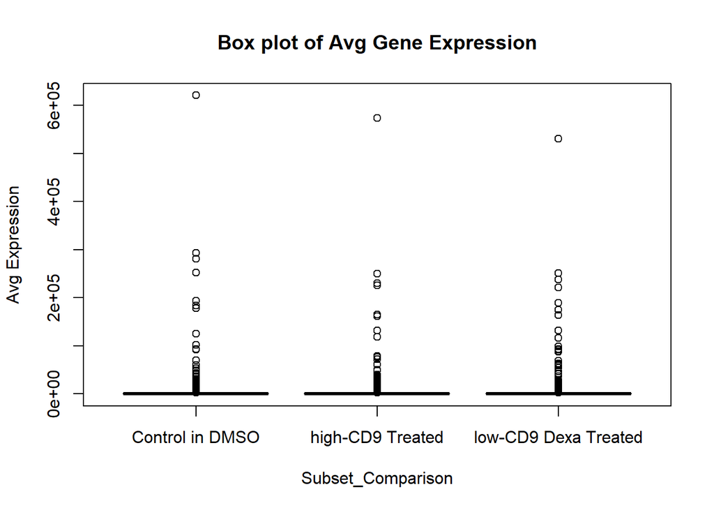

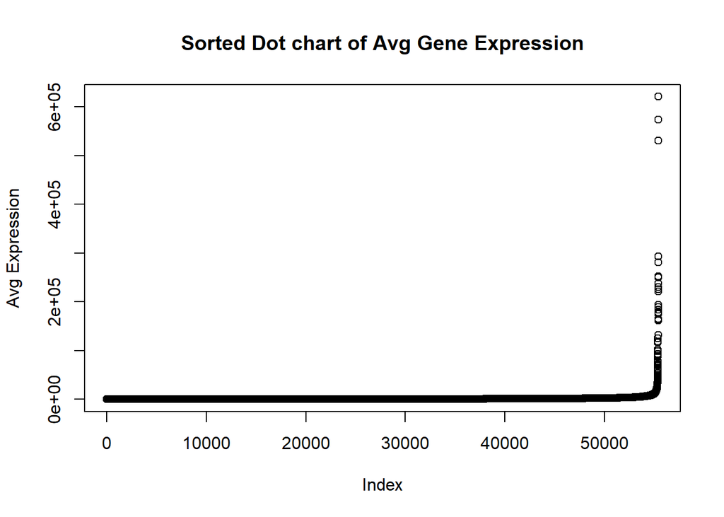

[output not shown]

## 3.6 Question 3.g. Create a volcano plot of the differential expression analysis that was performed on the downloaded data and describe how to interpret this plot. Use ggplot2!

A volcano plot is a visualization tool used in gene expression analysis to identify genes that have undergone significant changes in expression between two experimental conditions. By plotting the log2 fold change on the x-axis and the negative log10 p-value on the y-axis, volcano plots allow quick assessment of both the magnitude and statistical significance of gene expression differences.

Genes located in the upper right quadrant of the plot represent genes that have been significantly up-regulated (increased expression) with high statistical significance. Conversely, genes in the upper left quadrant indicate significant down-regulation (decreased expression). Genes near the center of the plot have minimal changes in expression.

The addition of threshold lines to the volcano plot can further aid in the interpretation of results. Horizontal lines can be used to define a p-value cutoff, while vertical lines can be used to specify a fold change threshold. Genes that exceed both thresholds are considered to be the most biologically relevant.

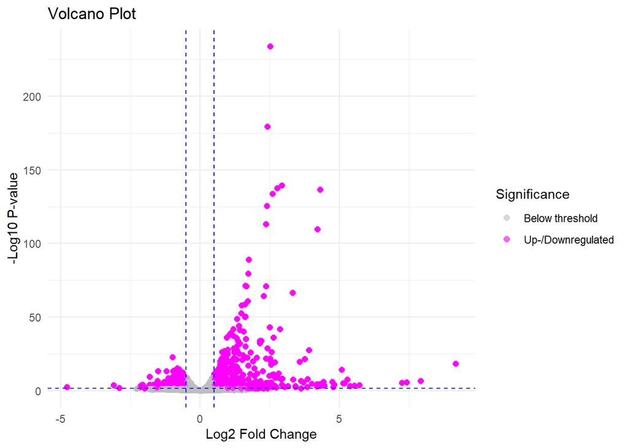

## 3.7 Question 3.h. Create a MA plot of the data using the ggplot2 plotting package. Describe how to interpret this plot.

An MA plot is a graphical tool used to visualize and interpret gene expression data. By plotting the average expression level (A) on the x-axis and the log fold change (M) on the y-axis, MA plots provide a clear representation of the relationship between gene expression and differential expression between two conditions.

Genes located far from the horizontal line at M = 0 indicate significant changes in expression, with points above the line representing up-regulation and points below the line representing down-regulation. The distance from the line corresponds to the magnitude of the fold change, with larger distances indicating more significant changes.

The distribution of points on an MA plot can reveal trends in the data set. For example, if there are more points above the M = 0 line, it may suggest a general trend toward up-regulation in the treatment condition. Additionally, clusters of points in certain areas can indicate groups of co-regulated genes or shared biological pathways.

MA plots can also help identify potential biases in the data. For example, if the points show a systematic shift in M values as a function of A (e.g., more down-regulated genes at low expression levels), it may indicate that lowly expressed genes are not reliably measured. This type of bias, known as a “low-expression bias,” can affect the interpretation of differential expression results.

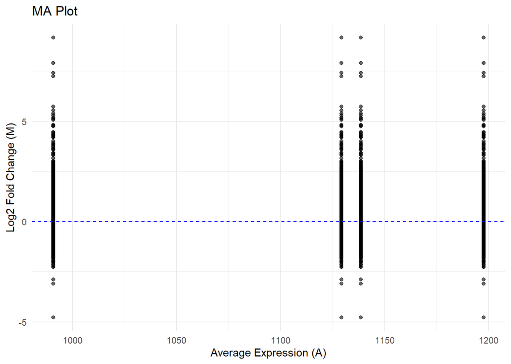

# 4 Question 4

## 4.1 Loading the downloaded data from UCI into R, and clean up the data set.

```r
#### Get the working directory and set to a new working directory to obtain the data ####
getwd()
```

```
## [1] "C:/Users/nessi/Documents/RBIF111"
```

```r
setwd("~/RBIF111/wk1/iris")

#### Read in the data as CSV and name all the columns ####
iris_data <- read.csv("iris.data", header = FALSE)
names(iris_data) <- c("sepal_length (cm)", "sepal_width (cm)", "petal_length (cm)", "petal_width (cm)", "class")
View(iris_data)
```

## 4.2 Create a function to calculate the amount of missing values, the mean, median, and standard deviation.

```r
#### Create the function ####
stats_1 <- function(df) {
  #### check for numeric values in columns ####
  cols_num <- sapply(df, is.numeric)
  #### take only numeric columns ####
  df_num <- df[, cols_num]

  #### calculate the statistics of numeric columns ####
  stats_1a <- data.frame(
    column = names(df_num),
    missing_val = sapply(df_num, function(x) sum(is.na(x))),
    mean = sapply(df_num, function(x) mean(x, na.rm=TRUE)),
    median = sapply(df_num, function(x) median(x, na.rm=TRUE)),
    std_dev= sapply(df_num, function(x) sd(x, na.rm=TRUE))
  )
  return(stats_1a)
}

#### Execute the function ####
stats_num <- stats_1(iris_data)
print("Numeric Stats")
```

```
## [1] "Numeric Stats"
```

```r
print(stats_num)
```

```
##                              column missing_val     mean median   std_dev
## sepal_length (cm) sepal_length (cm)           0 5.843333   5.80 0.8280661
## sepal_width (cm)   sepal_width (cm)           0 3.054000   3.00 0.4335943
## petal_length (cm) petal_length (cm)           0 3.758667   4.35 1.7644204
## petal_width (cm)   petal_width (cm)           0 1.198667   1.30 0.7631607
```

## 4.3 Visualizing the numerical statistical results as box plots.

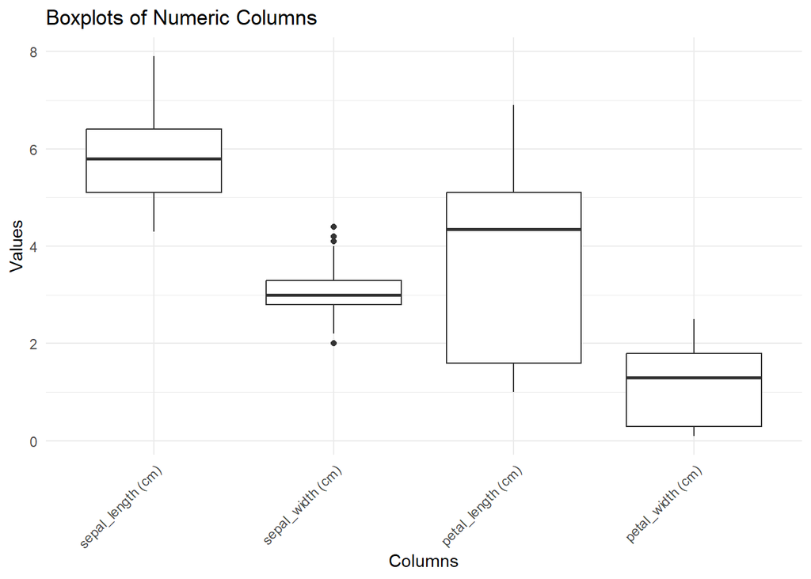

## 4.4 Calculate the total amount of categorical values in the data set.

```r
#### Get the column containing categorical values ####
col_categ <- iris_data$class
#### Count the amount for each category ####
categ_counts <- table(col_categ, useNA = "ifany")

#### Print the results####
print("Count of categorical values")
```

```
## [1] "Count of categorical values"
```

```r
print(categ_counts)
```

```
## col_categ
##     Iris-setosa Iris-versicolor  Iris-virginica
##              50              50              50
```

## 4.5 In the case of categorical values, it’s helpful to use a bar graph to dinstinguish the total count for each category because it’s an integer value and not a statistical result. The code below will visualize the categorical count as a bar graph instead of a box plot.

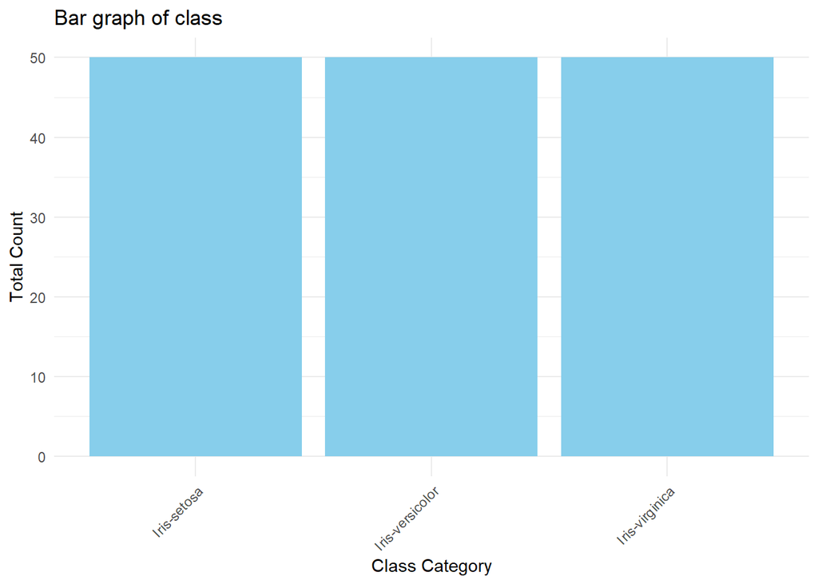